# Derek_Bowdle_HW_6

Title: Conditional GAN  
Author: Derek Bowdle

The goal is to train a conditional Generative Advesarial Network (GAN) that when given any handwritten even number it can generate the subsequent odd number.

I adapted a version of the pix2pix model written in python using tensorflow, to my own version that accepts 32x32x1 images instead of 256x256x3. The model has slightly fewer layers than the original architecture but is functionally the same.

## Import Libraries, Load, Pair, and Prepare Data

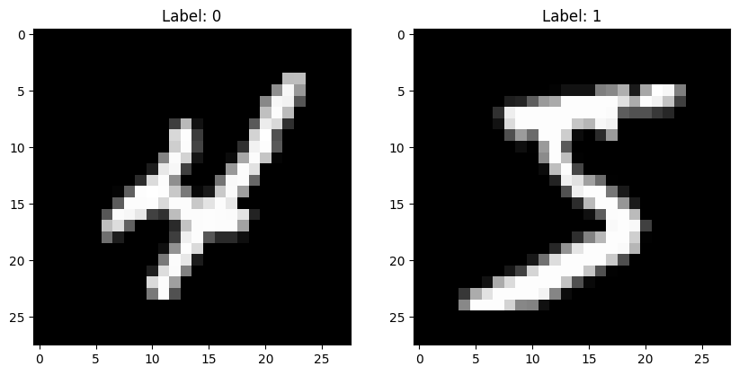

```python
import tensorflow as tf
from tensorflow import cast
import numpy as np
import matplotlib.pyplot as plt

import os
import pathlib
import time
import datetime

from IPython import display

# Load the MNIST dataset
(mnist_images, mnist_labels), (mnist_test_images, mnist_test_labels) = tf.keras.datasets.mnist.load_data()

# Function to pair even digits with the subsequent odd digits
def pair_even_odd_images(images, labels):
    even_images = []
    odd_images = []
    paired_labels = []

    # Iterate through all labels and images, filter even digits and pair them with their subsequent odd digit
    for i in range(len(labels)):
        if labels[i] % 2 == 0:  # Check if the label is even
            even_image = images[i]
            even_label = labels[i]
            # Find the next odd image
            for j in range(len(labels)):
                if labels[j] == even_label + 1:
                    odd_image = images[j]
                    even_images.append(even_image)
                    odd_images.append(odd_image)
                    paired_labels.append((even_label, labels[j]))
                    break

    return np.array(even_images), np.array(odd_images), np.array(paired_labels)

# Pair the images and labels
input_images, output_images, paired_labels = pair_even_odd_images(mnist_images, mnist_labels) #29492 2 28 28
# Pair test images
input_images_test, output_images_test, paired_labels_test = pair_even_odd_images(mnist_test_images, mnist_test_labels) #29492 2 28 28


# Example to visualize the first pair
plt.figure(figsize=(10, 5))

# Display the even digit
plt.subplot(1, 2, 1)
plt.imshow(input_images[3], cmap='gray')
plt.title(f'Label: {paired_labels[0][0]}')

# Display its subsequent odd digit
plt.subplot(1, 2, 2)
plt.imshow(output_images[3], cmap='gray')
plt.title(f'Label: {paired_labels[0][1]}')

plt.show()
```

```python
# The facade training set consist of 400 images
BUFFER_SIZE = 400
# The batch size of 1 produced better results for the U-Net in the original pix2pix experiment
BATCH_SIZE = 1
# Each image is 28x28 in size
IMG_WIDTH = 28
IMG_HEIGHT = 28

NEW_IMG_WIDTH = 32
NEW_IMG_HEIGHT = 32

def resize(input_image, real_image, height, width):
  input_image = tf.image.resize(input_image, [height, width],
                                method=tf.image.ResizeMethod.NEAREST_NEIGHBOR)
  real_image = tf.image.resize(real_image, [height, width],
                               method=tf.image.ResizeMethod.NEAREST_NEIGHBOR)

  return input_image, real_image

def random_crop(input_image, real_image):
  stacked_image = tf.stack([input_image, real_image], axis=0)
  cropped_image = tf.image.random_crop(
      stacked_image, size=[2, NEW_IMG_HEIGHT, NEW_IMG_WIDTH, input_image.shape[2]])

  return cropped_image[0], cropped_image[1]

# Normalizing the images to [-1, 1]
def normalize(input_image, real_image):
  input_image = (cast(input_image, tf.float32) / 127.5) - 1
  real_image = (cast(real_image, tf.float32) / 127.5) - 1

  return input_image, real_image

@tf.function()
def random_jitter(input_image, real_image):
  input_image, real_image = resize(input_image, real_image, 38, 38)
  # Random cropping back to 256x256
  input_image, real_image = random_crop(input_image, real_image)
  if tf.random.uniform(()) > 0.5:
    # Random mirroring
    input_image = tf.image.flip_left_right(input_image)
    real_image = tf.image.flip_left_right(real_image)

  return input_image, real_image

def jitter_images(dataset):
    def _jitter_function(input_image, real_image):
        return random_jitter(input_image, real_image)
    return dataset.map(_jitter_function)
```

## Build an input pipeline

```python
#training images
input_images = input_images[..., tf.newaxis].astype("float32")
output_images = output_images[..., tf.newaxis].astype("float32")

#test images
input_images_test = input_images_test[..., tf.newaxis].astype("float32")
output_images_test = output_images_test[..., tf.newaxis].astype("float32")

train_dataset = tf.data.Dataset.from_tensor_slices((input_images, output_images))
test_dataset = tf.data.Dataset.from_tensor_slices((input_images_test, output_images_test))

train_dataset = jitter_images(train_dataset)
test_dataset = jitter_images(test_dataset)

# Shuffle, batch, and prefetch the training dataset
BUFFER_SIZE = 400  # Adjust this size as needed
BATCH_SIZE = 1  # Typically 32 or 64

train_dataset = train_dataset.shuffle(BUFFER_SIZE).batch(BATCH_SIZE).prefetch(tf.data.AUTOTUNE)
test_dataset = test_dataset.batch(BATCH_SIZE).prefetch(tf.data.AUTOTUNE)
```

### Test an Image

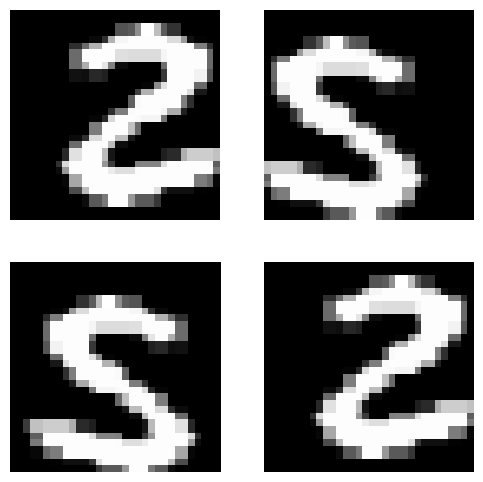

```python
inp, re = input_images[10], output_images[10]

plt.figure(figsize=(6, 6))
for i in range(4):
  rj_inp, rj_re = random_jitter(inp, re) #input then real
  plt.subplot(2, 2, i + 1)
  plt.imshow(rj_inp/255, cmap='gray')
  plt.axis('off')
plt.show()
inp, re = rj_inp, rj_re
```

## Build Generator

Define the downsampler (encoder):

```python
OUTPUT_CHANNELS = 1
```

```python
def downsample(filters, size, apply_batchnorm=True):
  initializer = tf.random_normal_initializer(0., 0.02)

  result = tf.keras.Sequential()
  result.add(
      tf.keras.layers.Conv2D(filters, size, strides=2, padding='same',
                             kernel_initializer=initializer, use_bias=False))

  if apply_batchnorm:
    result.add(tf.keras.layers.BatchNormalization())

  result.add(tf.keras.layers.LeakyReLU())

  return result
```

Define the upsampler (decoder):

```python
def upsample(filters, size, apply_dropout=False):
  initializer = tf.random_normal_initializer(0., 0.02)

  result = tf.keras.Sequential()
  result.add(
    tf.keras.layers.Conv2DTranspose(filters, size, strides=2,
                                    padding='same',
                                    kernel_initializer=initializer,
                                    use_bias=False))

  result.add(tf.keras.layers.BatchNormalization())

  if apply_dropout:
      result.add(tf.keras.layers.Dropout(0.5))

  result.add(tf.keras.layers.ReLU())

  return result
```

Define the generator with the downsampler and the upsampler:

```python
def Generator():
  inputs = tf.keras.layers.Input(shape=[32, 32, 1])

  down_stack = [
      downsample(32, 4, apply_batchnorm=False),
      downsample(64, 4),
      downsample(128, 4),
      downsample(128, 4),
      downsample(128, 4),
      # MNIST images are smaller, so fewer layers are needed.
  ]

  up_stack = [
      upsample(128, 4, apply_dropout=True),
      upsample(128, 4, apply_dropout=True),
      #upsample(128, 4, apply_dropout=True),
      upsample(64, 4),
      upsample(32, 4),
  ]

  initializer = tf.random_normal_initializer(0., 0.02)
  last = tf.keras.layers.Conv2DTranspose(OUTPUT_CHANNELS, 4,
                                         strides=2,
                                         padding='same',
                                         kernel_initializer=initializer,
                                         activation='tanh')

  x = inputs

  # Downsampling through the model
  skips = []
  for down in down_stack:
    x = down(x)
    skips.append(x)

  skips = reversed(skips[:-1])

  # Upsampling and establishing the skip connections
  for up, skip in zip(up_stack, skips):
    x = up(x)
    x = tf.keras.layers.Concatenate()([x, skip])

  x = last(x)

  return tf.keras.Model(inputs=inputs, outputs=x)
```

Visualize the generator model architecture:

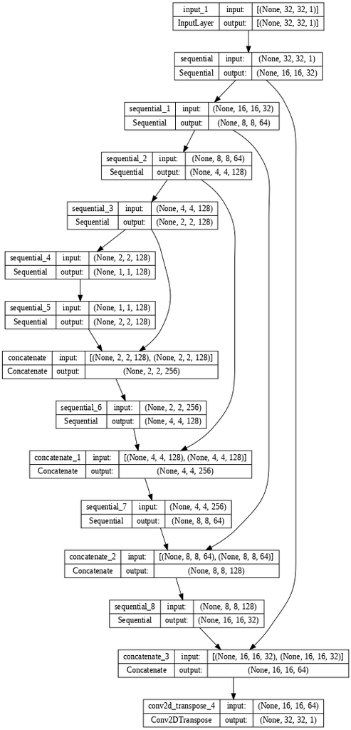

```python
generator = Generator()
tf.keras.utils.plot_model(generator, show_shapes=True, dpi=64)
```

Test the generator:

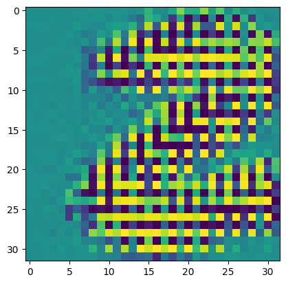

```python
gen_output = generator(inp[tf.newaxis, ...], training=False)
plt.imshow(gen_output[0, ...])
```

### Define the generator loss

```python
LAMBDA = 100
```

```python
loss_object = tf.keras.losses.BinaryCrossentropy(from_logits=True)
```

```python
def generator_loss(disc_generated_output, gen_output, target):
  gan_loss = loss_object(tf.ones_like(disc_generated_output), disc_generated_output)

  # Mean absolute error
  l1_loss = tf.reduce_mean(tf.abs(target - gen_output))

  total_gen_loss = gan_loss + (LAMBDA * l1_loss)

  return total_gen_loss, gan_loss, l1_loss
```

The training procedure for the generator is as follows:

[figure not shown]

## Build the discriminator

Let's define the discriminator:

```python
def Discriminator():
  initializer = tf.random_normal_initializer(0., 0.02)

  inp = tf.keras.layers.Input(shape=[32, 32, 1], name='input_image')
  tar = tf.keras.layers.Input(shape=[32, 32, 1], name='target_image')

  x = tf.keras.layers.concatenate([inp, tar])

  down1 = downsample(16, 4, False)(x)

  zero_pad1 = tf.keras.layers.ZeroPadding2D()(down1)
  conv = tf.keras.layers.Conv2D(64, 4, strides=1,
                                kernel_initializer=initializer,
                                use_bias=False)(zero_pad1)

  batchnorm1 = tf.keras.layers.BatchNormalization()(conv)

  leaky_relu = tf.keras.layers.LeakyReLU()(batchnorm1)

  zero_pad2 = tf.keras.layers.ZeroPadding2D()(leaky_relu)

  last = tf.keras.layers.Conv2D(1, 4, strides=1,
                                kernel_initializer=initializer)(zero_pad2)

  return tf.keras.Model(inputs=[inp, tar], outputs=last)
```

Visualize the discriminator model architecture:

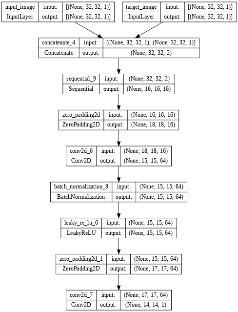

```python
discriminator = Discriminator()
tf.keras.utils.plot_model(discriminator, show_shapes=True, dpi=64)
```

Test the discriminator:

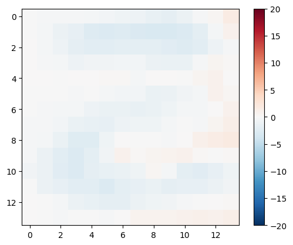

```python
disc_out = discriminator([inp[tf.newaxis, ...], gen_output], training=False)
plt.imshow(disc_out[0, ..., -1], vmin=-20, vmax=20, cmap='RdBu_r')
plt.colorbar()
```

### Define the discriminator loss

- The `discriminator_loss` function takes 2 inputs: **real images** and **generated images**.
- `real_loss` is a sigmoid cross-entropy loss of the **real images** and an **array of ones(since these are the real images)**.
- `generated_loss` is a sigmoid cross-entropy loss of the **generated images** and an **array of zeros (since these are the fake images)**.
- The `total_loss` is the sum of `real_loss` and `generated_loss`.

```python
def discriminator_loss(disc_real_output, disc_generated_output):
  real_loss = loss_object(tf.ones_like(disc_real_output), disc_real_output)

  generated_loss = loss_object(tf.zeros_like(disc_generated_output), disc_generated_output)

  total_disc_loss = real_loss + generated_loss

  return total_disc_loss
```

The training procedure for the discriminator is shown below.

To learn more about the architecture and the hyperparameters you can refer to the [pix2pix paper](https://arxiv.org/abs/1611.07004){:.external}.

[figure not shown]

## Define the optimizers and a checkpoint-saver

```python
generator_optimizer = tf.keras.optimizers.Adam(2e-4, beta_1=0.5)
discriminator_optimizer = tf.keras.optimizers.Adam(2e-4, beta_1=0.5)
```

```python
checkpoint_dir = './training_checkpoints'
checkpoint_prefix = os.path.join(checkpoint_dir, "ckpt")
checkpoint = tf.train.Checkpoint(generator_optimizer=generator_optimizer,
                                 discriminator_optimizer=discriminator_optimizer,
                                 generator=generator,
                                 discriminator=discriminator)
```

## Generate images

Write a function to plot some images during training.

- Pass images from the test set to the generator.
- The generator will then translate the input image into the output.
- The last step is to plot the predictions and *voila*!

Note: The `training=True` is intentional here since you want the batch statistics, while running the model on the test dataset. If you use `training=False`, you get the accumulated statistics learned from the training dataset (which you don't want).

```python
def generate_images(model, test_input, tar):
  prediction = model(test_input, training=True)
  plt.figure(figsize=(15, 15))

  display_list = [test_input[0], tar[0], prediction[0]]
  title = ['Input Image', 'Ground Truth', 'Predicted Image']

  for i in range(3):
    plt.subplot(1, 3, i+1)
    plt.title(title[i])
    # Getting the pixel values in the [0, 1] range to plot.
    plt.imshow(display_list[i] * 0.5 + 0.5)
    plt.axis('off')
  plt.show()
```

Test the function:

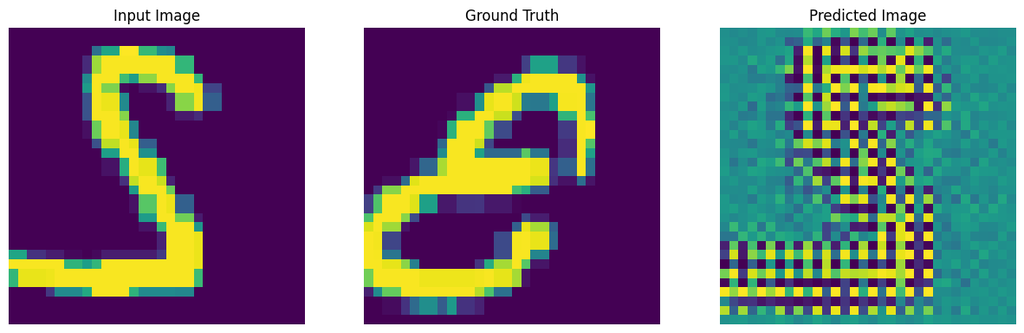

```python
for example_input, example_target in test_dataset.take(1):
  generate_images(generator, example_input, example_target)
```

## Training

```python
log_dir="logs/"

summary_writer = tf.summary.create_file_writer(
  log_dir + "fit/" + datetime.datetime.now().strftime("%Y%m%d-%H%M%S"))
```

```python
@tf.function
def train_step(input_image, target, step):
  with tf.GradientTape() as gen_tape, tf.GradientTape() as disc_tape:
    gen_output = generator(input_image, training=True)

    disc_real_output = discriminator([input_image, target], training=True)
    disc_generated_output = discriminator([input_image, gen_output], training=True)

    gen_total_loss, gen_gan_loss, gen_l1_loss = generator_loss(disc_generated_output, gen_output, target)
    disc_loss = discriminator_loss(disc_real_output, disc_generated_output)

  generator_gradients = gen_tape.gradient(gen_total_loss,
                                          generator.trainable_variables)
  discriminator_gradients = disc_tape.gradient(disc_loss,
                                               discriminator.trainable_variables)

  generator_optimizer.apply_gradients(zip(generator_gradients,
                                          generator.trainable_variables))
  discriminator_optimizer.apply_gradients(zip(discriminator_gradients,
                                              discriminator.trainable_variables))

  with summary_writer.as_default():
    tf.summary.scalar('gen_total_loss', gen_total_loss, step=step//1000)
    tf.summary.scalar('gen_gan_loss', gen_gan_loss, step=step//1000)
    tf.summary.scalar('gen_l1_loss', gen_l1_loss, step=step//1000)
    tf.summary.scalar('disc_loss', disc_loss, step=step//1000)


def fit(train_ds, test_ds, steps):
  example_input, example_target = next(iter(test_ds.take(1)))
  start = time.time()

  for step, (input_image, target) in train_ds.repeat().take(steps).enumerate():
    if (step) % 1000 == 0:
      display.clear_output(wait=True)

      if step != 0:
        print(f'Time taken for 1000 steps: {time.time()-start:.2f} sec\n')

      start = time.time()

      generate_images(generator, example_input, example_target)
      print(f"Step: {step//1000}k")

    train_step(input_image, target, step)

    # Training step
    if (step+1) % 10 == 0:
      print('.', end='', flush=True)


    # Save (checkpoint) the model every 5k steps
    if (step + 1) % 5000 == 0:
      checkpoint.save(file_prefix=checkpoint_prefix)
```

```python
%load_ext tensorboard
%tensorboard --logdir {log_dir}
```

Training loop

```
Time taken for 1000 steps: 9.40 sec
```

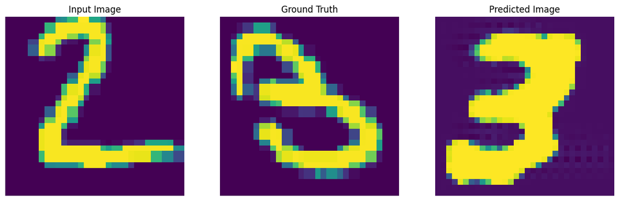

```
Step: 39k
....................................................................................................
```

```python
fit(train_dataset, test_dataset, steps=40000)
```

### Training curves for G and D

gen_gan_loss is the training curve for the generator, disc_loss is the training curve for the discriminator and gen_l1_loss is the change in Mean Absolute Error (MAE) over time. You can see that l1 decreases as we train meaning the overall network is improving, but it appears that the discriminator has somewhat overpowered the generator. The generator was still able to produce satesfactory results from a qualitative perspective but a future thing to improve would be to further balance the generator and discriminator.

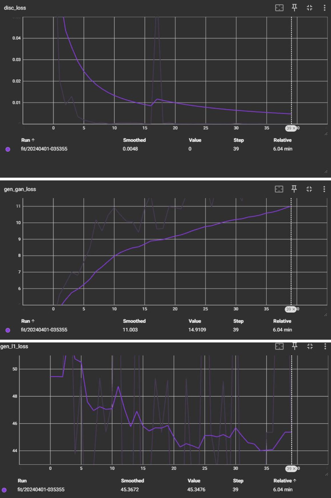

## Restore the latest checkpoint and test the network

```python
!ls {checkpoint_dir}
```

```
checkpoint		    ckpt-3.index		ckpt-6.index
ckpt-1.data-00000-of-00001  ckpt-4.data-00000-of-00001	ckpt-7.data-00000-of-00001
ckpt-1.index		    ckpt-4.index		ckpt-7.index
ckpt-2.data-00000-of-00001  ckpt-5.data-00000-of-00001	ckpt-8.data-00000-of-00001
ckpt-2.index		    ckpt-5.index		ckpt-8.index
ckpt-3.data-00000-of-00001  ckpt-6.data-00000-of-00001
```

```python
# Restoring the latest checkpoint in checkpoint_dir
checkpoint.restore(tf.train.latest_checkpoint(checkpoint_dir))
```

```
<tensorflow.python.checkpoint.checkpoint.CheckpointLoadStatus at 0x7f55a7daff40>
```

## Examples for digits

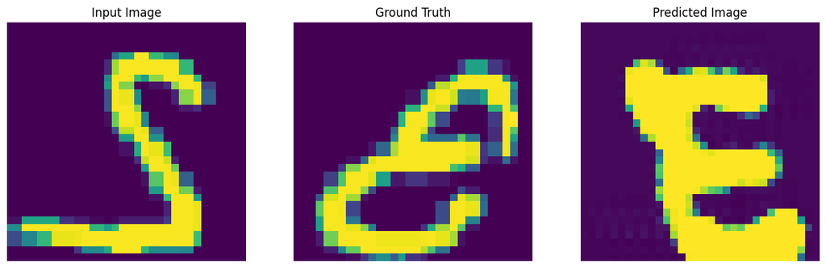

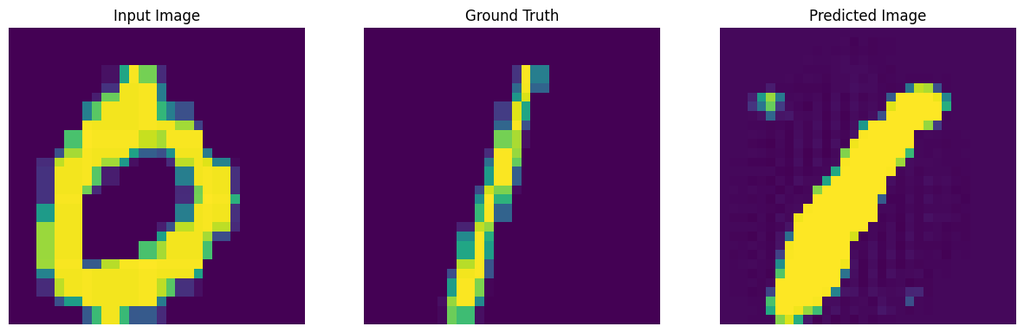

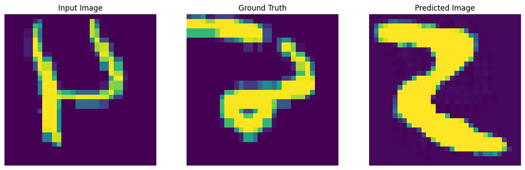

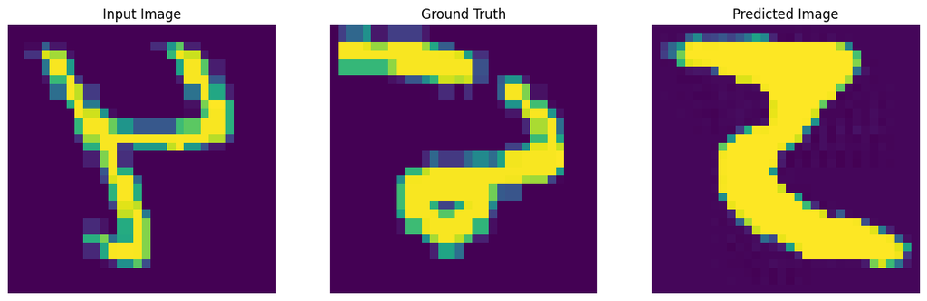

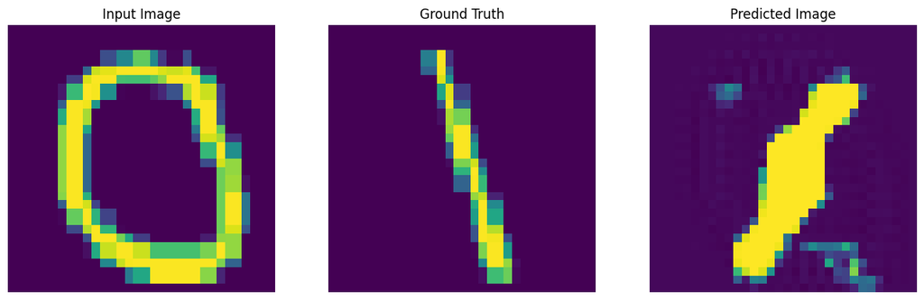

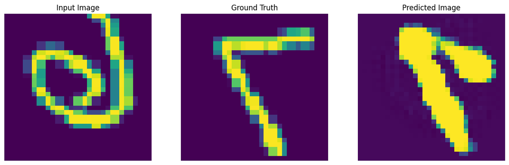

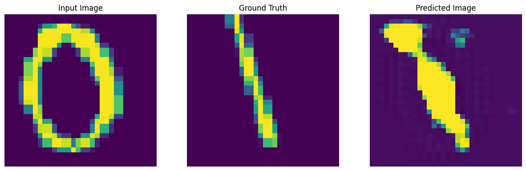

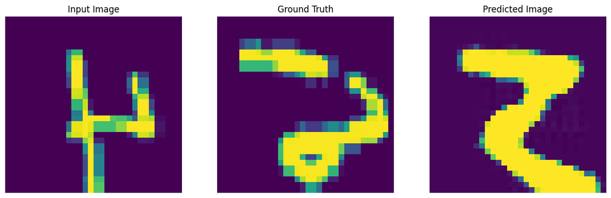

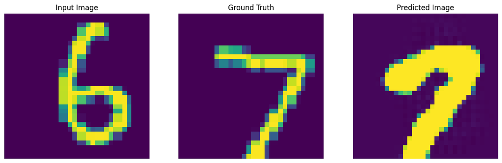

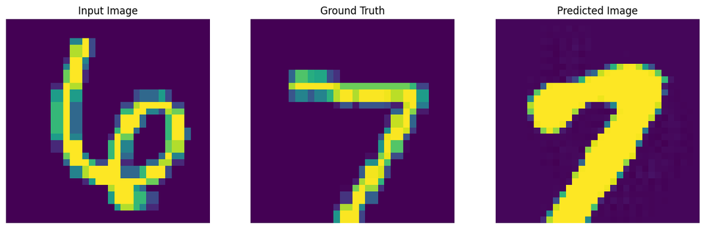

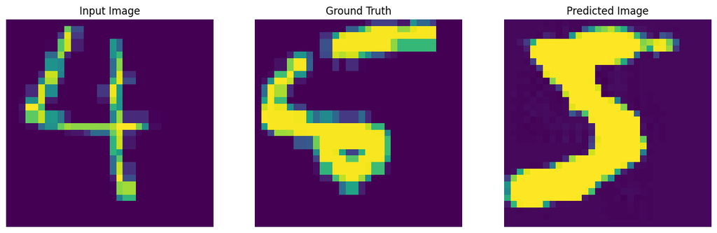

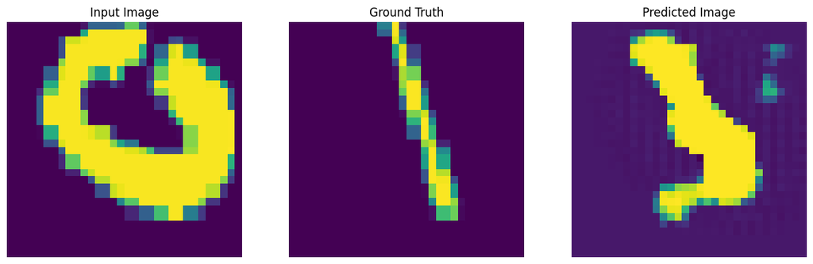

[28 more figures not shown]

```python
# Run the trained model on a few examples from the test set
for inp, tar in test_dataset.take(40):
  generate_images(generator, inp, tar)
```